# Statistical Inference Course Project Part 2

Author: Norman Benbrahim

**Overview** In the second portion of the class, we’re going to analyze the ToothGrowth data in the R datasets package.

# Question 1

*Load the ToothGrowth data and perform some basic exploratory data analyses*

```r
library(datasets)
library(ggplot2)
str(ToothGrowth)
```

```
## 'data.frame':    60 obs. of  3 variables:
##  $ len : num  4.2 11.5 7.3 5.8 6.4 10 11.2 11.2 5.2 7 ...
##  $ supp: Factor w/ 2 levels "OJ","VC": 2 2 2 2 2 2 2 2 2 2 ...
##  $ dose: num  0.5 0.5 0.5 0.5 0.5 0.5 0.5 0.5 0.5 0.5 ...
```

We see the data can be split into two categories based on `supp`, the supplement type. Let’s plot the dose in miligrams (`dose`) vs the tooth length (`len`) color coded by the supplement type

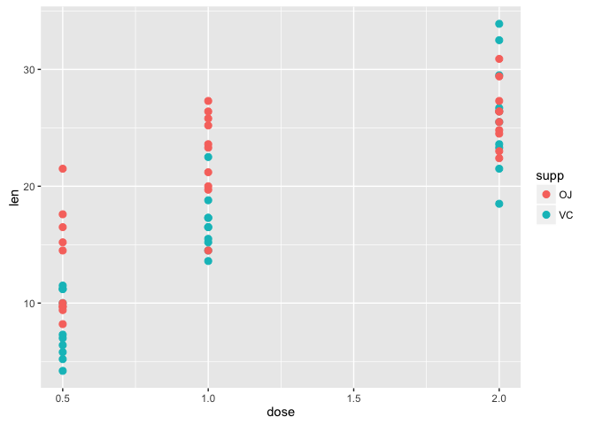

```r
g <- ggplot(ToothGrowth, aes(dose, len))
g <- g + geom_point(aes(colour = supp), size = 2.5)
g
```

Now in a boxplot

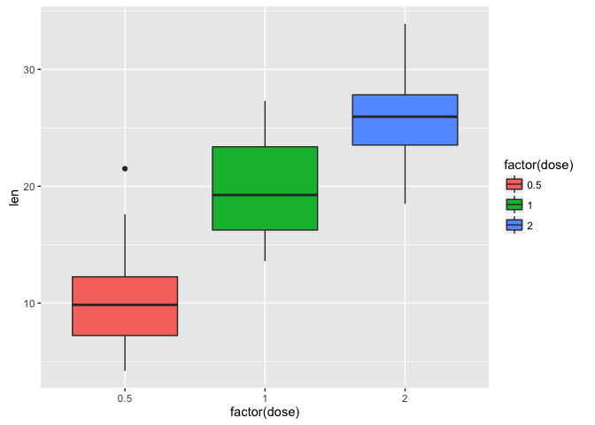

```r
g <- ggplot(ToothGrowth, aes(factor(dose), len))
g <- g + geom_boxplot(aes(fill = factor(dose)))
g
```

# Question 2

*Provide a basic summary of the data*

`R` has a summary function that can do this

```r
summary(ToothGrowth)
```

```
##       len        supp         dose
##  Min.   : 4.20   OJ:30   Min.   :0.500
##  1st Qu.:13.07   VC:30   1st Qu.:0.500
##  Median :19.25           Median :1.000
##  Mean   :18.81           Mean   :1.167
##  3rd Qu.:25.27           3rd Qu.:2.000
##  Max.   :33.90           Max.   :2.000
```

# Question 3

*Use confidence intervals and/or hypothesis tests to compare tooth growth by supp and dose. (Only use the techniques from class, even if there’s other approaches worth considering)*

Let’s do a simple t-test

```r
t.test(len ~ supp, data = ToothGrowth)
```

```
##
##  Welch Two Sample t-test
##
## data:  len by supp
## t = 1.9153, df = 55.309, p-value = 0.06063
## alternative hypothesis: true difference in means is not equal to 0
## 95 percent confidence interval:
##  -0.1710156  7.5710156
## sample estimates:
## mean in group OJ mean in group VC
##         20.66333         16.96333
```

In this case we see the null cannot be rejected because the p-value is higher than an alpha level of 0.05:

```r
t.test(len ~ supp, data = ToothGrowth)$p.value
```

```
## [1] 0.06063451
```

So we can not say with any confidence that supplement type have any impact on tooth growth. Let’s run 3 separate t tests now for each dose level. Since we’re running multiple tests, we need to correct for multiple comparisons. I will simply do a **Bonferonni correction**, and set the new significance level to $\alpha/m$ where m is the number of tests conducted. In this case $m=3$, so we get a new alpha $\alpha_b = 0.016$.

```r
library(dplyr)

d0.5to1 <- filter(ToothGrowth, dose %in% c(0.5, 1.0))
d1to2 <- filter(ToothGrowth, dose %in% c(1.0, 2.0))
d0.5to2 <- filter(ToothGrowth, dose %in% c(0.5, 2.0))
```

First we check the p values for dose levels 0.5 to 1 and also display their confidence intervals

```r
t.test(len ~ dose, data = d0.5to1)$p.value
```

```
## [1] 1.268301e-07
```

```r
t.test(len ~ dose, data = d0.5to1)$conf.int[1:2]
```

```
## [1] -11.983781  -6.276219
```

Much less than 0.016, the null can be rejected

Now check the levels 1 to 2

```r
t.test(len ~ dose, data = d1to2)$p.value
```

```
## [1] 1.90643e-05
```

```r
t.test(len ~ dose, data = d1to2)$conf.int[1:2]
```

```
## [1] -8.996481 -3.733519
```

Also much less than 0.016, the null can be rejected.

Finally, check levels 0.5 to 2

```r
t.test(len ~ dose, data = d0.5to2)$p.value
```

```
## [1] 4.397525e-14
```

```r
t.test(len ~ dose, data = d0.5to2)$conf.int[1:2]
```

```
## [1] -18.15617 -12.83383
```

Once again much less than 0.016. All the intervals do not contain 0, so our conclusions are firm.

# Question 4

*State your conclusions and the assumptions needed for your conclusions*